# Science Mapping Analysis with bibliometrix R-package: an example

Massimo Aria and Corrado Cuccurullo

July 31, 2018

# Bibliographic Collection

**Data source**: Clarivate Analytics Web of Science (http://apps.webofknowledge.com)

**Data format**: Plaintext

**Document Type**: Articles, letters, review and proceedings papers

**Query data**: May, 2018

# Install and load bibliometrix R-package

```r
# Stable version from CRAN (Comprehensive R Archive Network)
# if you need to execute the code, remove # from the beginning of the next line

# install.packages("bibliometrix")


# Most updated version from GitHub
# if you need to execute the code, remove # from the beginning of the next lines

# install.packages("devtools")

if(!isTRUE(require("bibliometrix"))){devtools::install_github("massimoaria/bibliometrix")}

library(bibliometrix)
```

# Data Loading and Converting

```r
# Converting the loaded files into a R bibliographic dataframe
M <- convert2df(D, dbsource="isi",format="bibtex")
```

```
Converting your isi collection into a bibliographic dataframe

Articles extracted   100
Articles extracted   200
Articles extracted   300
Articles extracted   400
Articles extracted   500
Done!


Generating affiliation field tag AU_UN from C1:  Done!
```

# Load ISI Fast 5k format

# Section 1: Descriptive Analysis

Although bibliometrics is mainly known for quantifying the scientific production and measuring its quality and impact, it is also useful for displaying and analysing the intellectual, conceptual and social structures of research as well as their evolution and dynamical aspects.

In this way, bibliometrics aims to describe how specific disciplines, scientific domains, or research fields are structured and how they evolve over time. In other words, bibliometric methods help to map the science (so-called science mapping) and are very useful in the case of research synthesis, especially for the systematic ones.

Bibliometrics is an academic science founded on a set of statistical methods, which can be used to analyze scientific big data quantitatively and their evolution over time and discover information. Network structure is often used to model the interaction among authors, papers/documents/articles, references, keywords, etc.

Bibliometrix is an open-source software for automating the stages of data-analysis and data-visualization. After converting and uploading bibliographic data in R, Bibliometrix performs a descriptive analysis and different research-structure analysis.

Descriptive analysis provides some snapshots about the annual research development, the top “k” productive authors, papers, countries and most relevant keywords.

## Main findings about the collection

```r
# options(width=160)
results <- biblioAnalysis(M)
summary(results, k=10, pause=F, width=130) #
```

```
Main Information about data

 Documents                             500
 Sources (Journals, Books, etc.)       205
 Keywords Plus (ID)                    1886
 Author's Keywords (DE)                1039
 Period                                2011 - 2019
 Average citations per documents       12.9

 Authors                               2374
 Author Appearances                    3082
 Authors of single-authored documents  13
 Authors of multi-authored documents   2361
 Single-authored documents             14

 Documents per Author                  0.211
 Authors per Document                  4.75
 Co-Authors per Documents              6.16
 Collaboration Index                   4.86

 Document types
 ARTICLE                         431
 ARTICLE, EARLY ACCESS           1
 ARTICLE, PROCEEDINGS PAPER      4
 CORRECTION                      2
 EDITORIAL MATERIAL              3
 MEETING ABSTRACT                1
 REVIEW                          57
 REVIEW, BOOK CHAPTER            1


Annual Scientific Production
```

| Year | Articles |
| --- | --- |
| 2011 | 10 |
| 2012 | 40 |
| 2013 | 43 |
| 2014 | 74 |
| 2015 | 59 |
| 2016 | 80 |
| 2017 | 88 |
| 2018 | 92 |
| 2019 | 13 |

```
Annual Percentage Growth Rate 3.333923


Most Productive Authors
```

|  | Authors | Articles | Authors | Articles Fractionalized |
| --- | --- | --- | --- | --- |
| 1 | GARCIA P | 18 | GARCIA P | 3.41 |
| 2 | RODRIGUEZ A | 14 | RODRIGUEZ A | 2.55 |
| 3 | SILLANKORVA S | 14 | SILLANKORVA S | 2.50 |
| 4 | AZEREDO J | 12 | AZEREDO J | 2.19 |
| 5 | MARTINEZ B | 11 | ANONYMOUS A | 2.00 |
| 6 | GUTIERREZ D | 10 | MARTINEZ B | 1.91 |
| 7 | LAVIGNE R | 10 | CHHIBBER S | 1.83 |
| 8 | WANG X | 9 | GUTIERREZ D | 1.72 |
| 9 | COTTRELL BJ | 7 | ABEDON ST | 1.50 |
| 10 | FERNANDEZ L | 7 | WOOD TK | 1.35 |

```
Top manuscripts per citations
```

|  | Paper | TC | TCperYear |
| --- | --- | --- | --- |
| 1 | CAMPOCCIA D, 2013, BIOMATERIALS | 473 | 78.83 |
| 2 | SHARON I, 2013, GENOME RES | 207 | 34.50 |
| 3 | ALBERTSEN M, 2012, ISME J | 116 | 16.57 |
| 4 | FORTIER LC, 2013, VIRULENCE | 112 | 18.67 |
| 5 | TURNBULL L, 2016, NAT COMMUN | 89 | 29.67 |
| 6 | ALEMAYEHU D, 2012, MBIO | 89 | 12.71 |
| 7 | RYAN EM, 2011, J PHARM PHARMACOL | 81 | 10.12 |
| 8 | BUCHANAN RL, 2017, FOOD CONTROL | 79 | 39.50 |
| 9 | THALLINGER B, 2013, BIOTECHNOL J | 76 | 12.67 |
| 10 | LEE JH, 2011, INFECT IMMUN | 62 | 7.75 |

```
Corresponding Author's Countries
```

|  | Country | Articles | Freq | SCP | MCP | MCP_Ratio |
| --- | --- | --- | --- | --- | --- | --- |
| 1 | USA | 97 | 0.1952 | 72 | 25 | 0.258 |
| 2 | CHINA | 47 | 0.0946 | 36 | 11 | 0.234 |
| 3 | GERMANY | 26 | 0.0523 | 11 | 15 | 0.577 |
| 4 | INDIA | 25 | 0.0503 | 25 | 0 | 0.000 |
| 5 | SPAIN | 25 | 0.0503 | 19 | 6 | 0.240 |
| 6 | KOREA | 22 | 0.0443 | 15 | 7 | 0.318 |
| 7 | PORTUGAL | 21 | 0.0423 | 13 | 8 | 0.381 |
| 8 | UNITED KINGDOM | 21 | 0.0423 | 14 | 7 | 0.333 |
| 9 | CANADA | 20 | 0.0402 | 14 | 6 | 0.300 |
| 10 | AUSTRALIA | 19 | 0.0382 | 11 | 8 | 0.421 |

```
SCP: Single Country Publications

MCP: Multiple Country Publications


Total Citations per Country
```

|  | Country | Total Citations | Average Article Citations |
| --- | --- | --- | --- |
| 1 | ARGENTINA | 11 | 3.67 |
| 2 | AUSTRALIA | 331 | 17.42 |
| 3 | AUSTRIA | 83 | 41.50 |
| 4 | BANGLADESH | 0 | 0.00 |
| 5 | BELGIUM | 82 | 20.50 |
| 6 | BRAZIL | 96 | 6.40 |
| 7 | CANADA | 356 | 17.80 |
| 8 | CHILE | 5 | 5.00 |
| 9 | CHINA | 347 | 7.38 |
| 10 | COLOMBIA | 11 | 5.50 |

```
Most Relevant Sources
```

|  | Sources | Articles |
| --- | --- | --- |
| 1 | FRONTIERS IN MICROBIOLOGY | 39 |
| 2 | PLOS ONE | 32 |
| 3 | APPLIED AND ENVIRONMENTAL MICROBIOLOGY | 22 |
| 4 | SCIENTIFIC REPORTS | 16 |
| 5 | MICROBIOLOGY-SGM | 13 |
| 6 | JOURNAL OF BACTERIOLOGY | 11 |
| 7 | BMC MICROBIOLOGY | 10 |
| 8 | VIRUSES-BASEL | 10 |
| 9 | ANTIMICROBIAL AGENTS AND CHEMOTHERAPY | 8 |
| 10 | APPLIED MICROBIOLOGY AND BIOTECHNOLOGY | 7 |

```
Most Relevant Keywords
```

|  | Author Keywords (DE) | Articles | Keywords-Plus (ID) | Articles |
| --- | --- | --- | --- | --- |
| 1 | BIOFILM | 120 | BIOFILM FORMATION | 128 |
| 2 | BACTERIOPHAGE | 73 | ESCHERICHIA COLI | 121 |
| 3 | BIOFILMS | 39 | PSEUDOMONAS AERUGINOSA | 72 |
| 4 | BACTERIOPHAGES | 35 | RESISTANCE | 61 |
| 5 | PSEUDOMONAS AERUGINOSA | 35 | INFECTIONS | 54 |
| 6 | PHAGE THERAPY | 31 | BACTERIOPHAGE | 51 |
| 7 | STAPHYLOCOCCUS AUREUS | 23 | PHAGE THERAPY | 50 |
| 8 | ANTIBIOTIC RESISTANCE | 16 | IN VITRO | 45 |
| 9 | ESCHERICHIA COLI | 14 | STAPHYLOCOCCUS AUREUS | 44 |
| 10 | PHAGE | 13 | PHAGE | 41 |

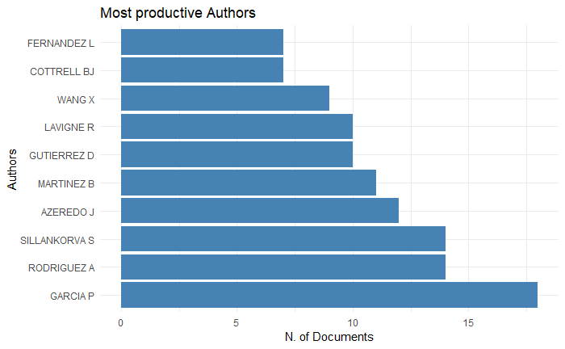

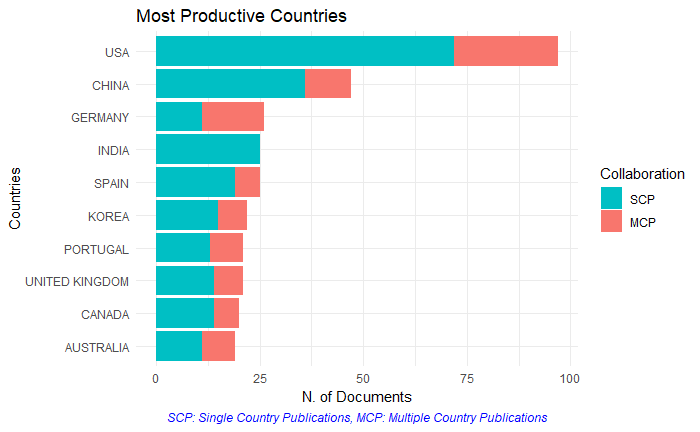

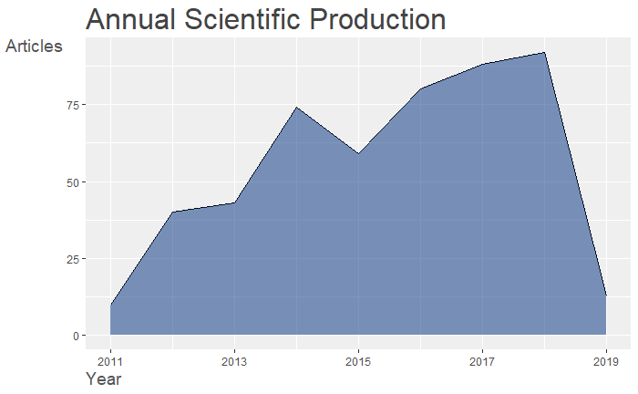

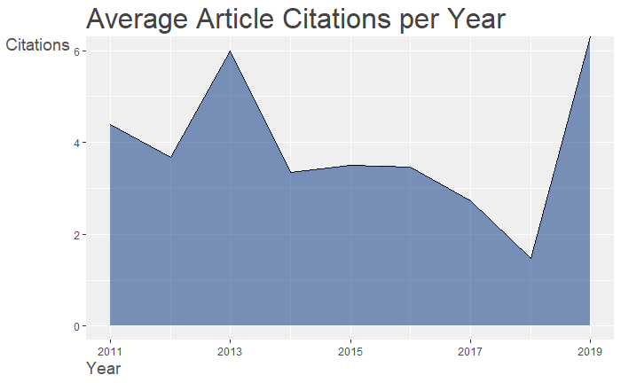

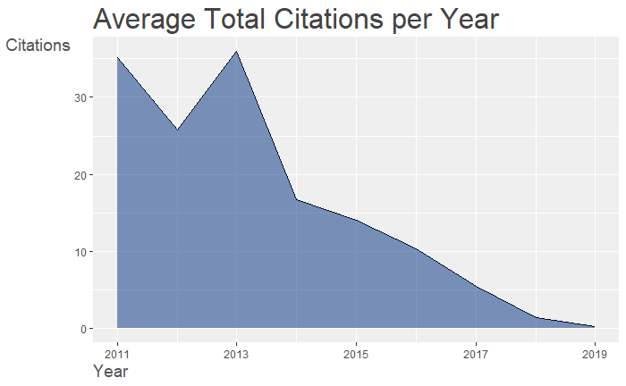

```r
plot(x=results, k=10, pause=F)
```

## Most Cited References

```r
CR <- citations(M, field = "article", sep = ";")
cbind(CR$Cited[1:20])
```

```
                                                                                          [,1]
FU WL, 2010, ANTIMICROB AGENTS CH, V54, P397, DOI 10.1128/AAC.00669-09.                     53
LABRIE SJ, 2010, NAT REV MICROBIOL, V8, P317, DOI 10.1038/NRMICRO2315.                      53
LU TK, 2007, P NATL ACAD SCI USA, V104, P11197, DOI 10.1073/PNAS.0704624104.                47
COSTERTON JW, 1999, SCIENCE, V284, P1318, DOI 10.1126/SCIENCE.284.5418.1318.                43
HUGHES KA, 1998, MICROBIOL-UK, V144, P3039, DOI 10.1099/00221287-144-11-3039.               42
AZEREDO J, 2008, CURR PHARM BIOTECHNO, V9, P261, DOI 10.2174/138920108785161604.            40
DONLAN RM, 2009, TRENDS MICROBIOL, V17, P66, DOI 10.1016/J.TIM.2008.11.002.                 39
SULAKVELIDZE A, 2001, ANTIMICROB AGENTS CH, V45, P649, DOI 10.1128/AAC.45.3.649-659.2001.   38
CURTIN JJ, 2006, ANTIMICROB AGENTS CH, V50, P1268, DOI 10.1128/AAC.50.4.1268-1275.2006.     35
SUTHERLAND IW, 2004, FEMS MICROBIOL LETT, V232, P1, DOI 10.1016/S0378-1097(04)00041-2.      35
CORNELISSEN A, 2011, PLOS ONE, V6, DOI 10.1371/JOURNAL.PONE.0018597.                        34
DONLAN RM, 2002, CLIN MICROBIOL REV, V15, P167, DOI 10.1128/CMR.15.2.167-193.2002.          33
ADAMS M, 1959, BACTERIOPHAGES.                                                              32
PIRES D, 2011, RES MICROBIOL, V162, P798, DOI 10.1016/J.RESMIC.2011.06.010.                 32
FLEMMING HC, 2010, NAT REV MICROBIOL, V8, P623, DOI 10.1038/NRMICRO2415.                    31
HANLON GW, 2001, APPL ENVIRON MICROB, V67, P2746, DOI 10.1128/AEM.67.6.2746-2753.2001.      31
CARSON L, 2010, FEMS IMMUNOL MED MIC, V59, P447, DOI 10.1111/J.1574-695X.2010.00696.X.      29
CERCA N, 2007, LETT APPL MICROBIOL, V45, P313, DOI 10.1111/J.1472-765X.2007.02190.X.        27
HOIBY N, 2010, INT J ANTIMICROB AG, V35, P322, DOI 10.1016/J.IJANTIMICAG.2009.12.011.       26
RICE SA, 2009, ISME J, V3, P271, DOI 10.1038/ISMEJ.2008.109.                                26
```

# Section 2: The Intellectual Structure of the field - Co-citation Analysis

Citation analysis is one of the main classic techniques in bibliometrics. It shows the structure of a specific field through the linkages between nodes (e.g. authors, papers, journal), while the edges can be differently interpretated depending on the network type, that are namely co-citation, direct citation, bibliographic coupling. Please see Aria, Cuccurullo (2017).

Below there are three examples.

First, a co-citation network that shows relations between cited-reference works (nodes).

Second, a co-citation network that uses cited-journals as unit of analysis.

The useful dimensions to comment the co-citation networks are: (i) centrality and peripherality of nodes, (ii) their proximity and distance, (iii) strength of ties, (iv) clusters, (iiv) bridging contributions.

Third, a historiograph is built on direct citations. It draws the intellectual linkages in a historical order. Cited works of thousands of authors contained in a collection of published scientific articles is sufficient for recostructing the historiographic structure of the field, calling out the basic works in it.

## Article (References) co-citation analysis

**Plot options**:

- n = 50 (the funxtion plots the main 50 cited references)
- type = “fruchterman” (the network layout is generated using the Fruchterman-Reingold Algorithm)
- size.cex = TRUE (the size of the vertices is proportional to their degree)
- size = 20 (the max size of vertices)
- remove.multiple=FALSE (multiple edges are not removed)
- labelsize = 0.7 (defines the size of vertex labels)
- edgesize = 10 (The thickness of the edges is proportional to their strength. Edgesize defines the max value of the thickness)
- edges.min = 5 (plots only edges with a strength greater than or equal to 5)
- all other arguments assume the default values

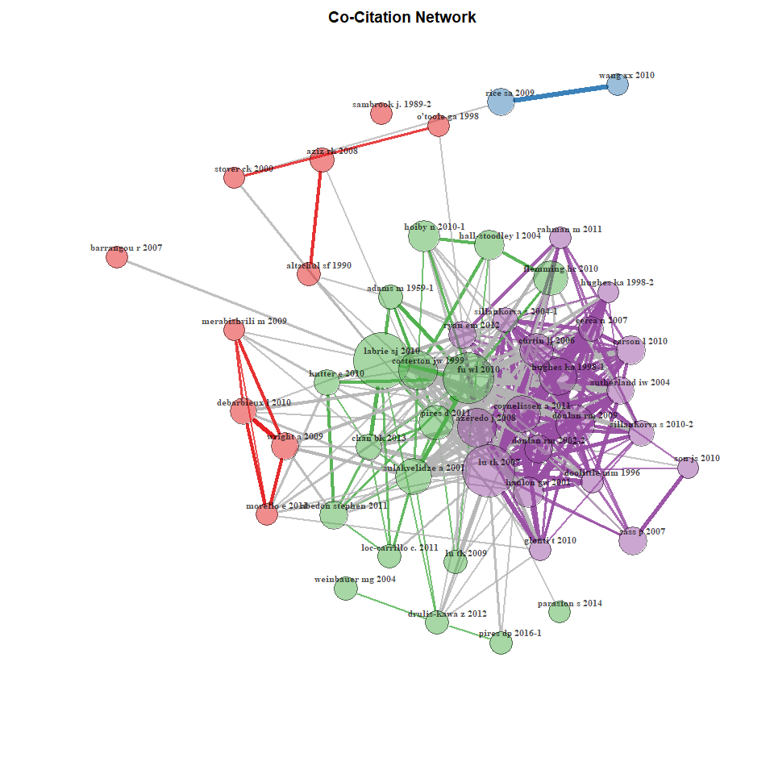

```r
NetMatrix <- biblioNetwork(M, analysis = "co-citation", network = "references", sep = ";")
net=networkPlot(NetMatrix, n = 50, Title = "Co-Citation Network", type = "fruchterman", size.cex=TRUE, size=20, remove.multiple=FALSE, labelsize=0.7,edgesize = 10, edges.min=5)
```

Descriptive analysis of Article co-citation network characteristics

```r
netstat <- networkStat(NetMatrix)
summary(netstat,k=10)
```

```
Main statistics about the network

 Size                                  20898
 Density                               0.006
 Transitivity                          0.494
 Diameter                              5
 Degree Centralization                 0.133
 Average path length                   2.802
```

## Journal (Source) co-citation analysis

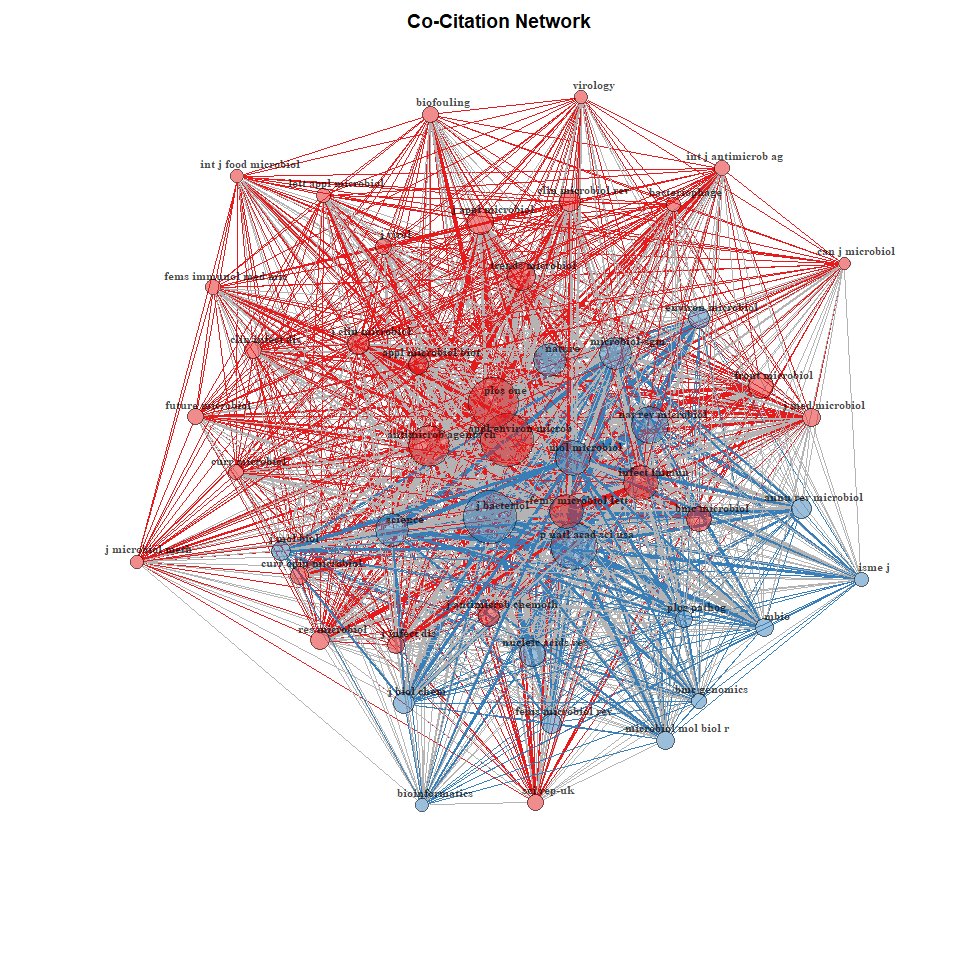

```r
M=metaTagExtraction(M,"CR_SO",sep=";")
NetMatrix <- biblioNetwork(M, analysis = "co-citation", network = "sources", sep = ";")
net=networkPlot(NetMatrix, n = 50, Title = "Co-Citation Network", type = "auto", size.cex=TRUE, size=15, remove.multiple=FALSE, labelsize=0.7,edgesize = 10, edges.min=5)
```

Descriptive analysis of Journal co-citation network characteristics

```r
netstat <- networkStat(NetMatrix)
summary(netstat,k=10)
```

[output not shown]

# Section 3: Historiograph - Direct citation linkages

```r
histResults <- histNetwork(M, min.citations=quantile(M$TC,0.75), sep = ";")
```

```r
options(width = 130)
net <- histPlot(histResults, n=20, size.cex=TRUE, size = 5, labelsize = 3, arrowsize = 0.5)
```

[output not shown]

# Section 4: The conceptual structure - Co-Word Analysis

Co-word networks show the conceptual structure, that uncovers links between concepts through term co-occurences.

Conceptual structure is often used to understand the topics covered by scholars (so-called research front) and identify what are the most important and the most recent issues.

Dividing the whole timespan in different timeslices and comparing the conceptual structures is useful to analyze the evolution of topics over time.

Bibliometrix is able to analyze keywords, but also the terms in the articles’ titles and abstracts. It does it using network analysis or correspondance analysis (CA) or multiple correspondance analysis (MCA). CA and MCA visualise the conceptual structure in a two-dimensional plot.

## Co-word Analysis through Keyword co-occurrences

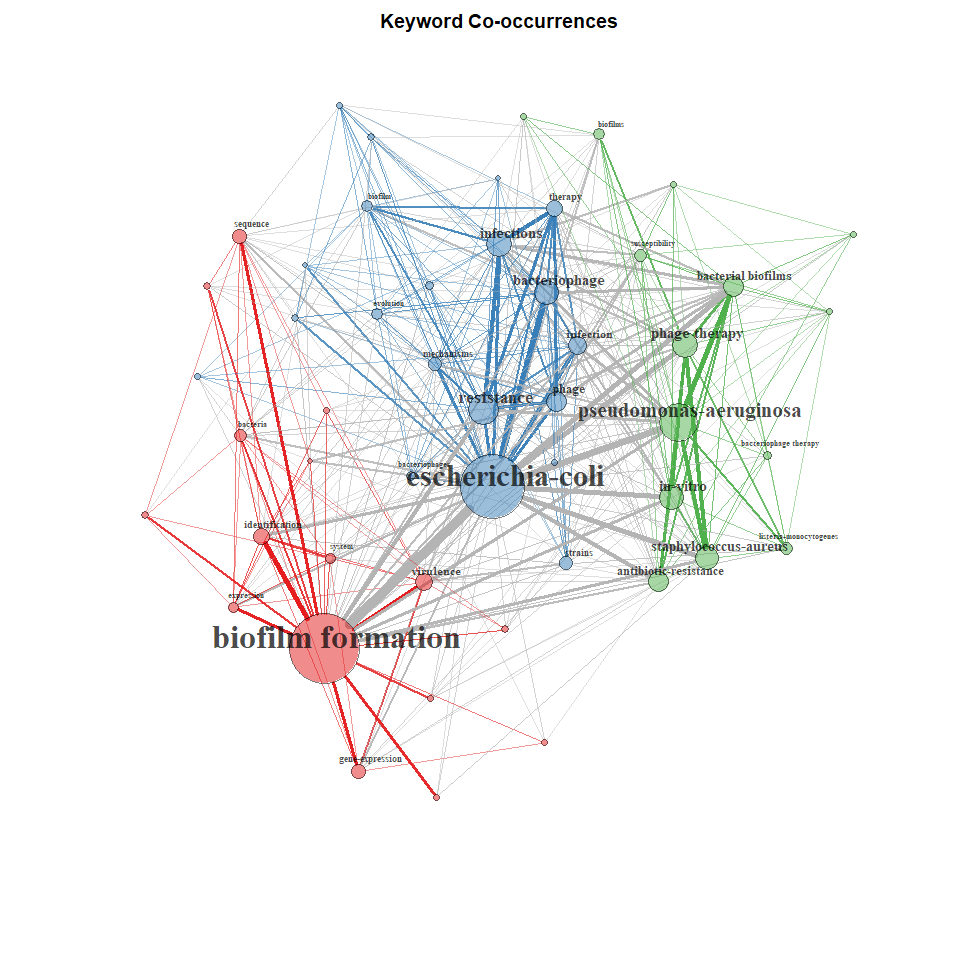

```r
NetMatrix <- biblioNetwork(M, analysis = "co-occurrences", network = "keywords", sep = ";")
net=networkPlot(NetMatrix, normalize="association", n = 50, Title = "Keyword Co-occurrences", type = "fruchterman", size.cex=TRUE, size=20, remove.multiple=F, edgesize = 10, labelsize=3,label.cex=TRUE,label.n=30,edges.min=2)
```

Descriptive analysis of keyword co-occurrences network characteristics

```r
netstat <- networkStat(NetMatrix)
summary(netstat,k=10)
```

[output not shown]

## Co-word Analysis through Correspondence Analysis

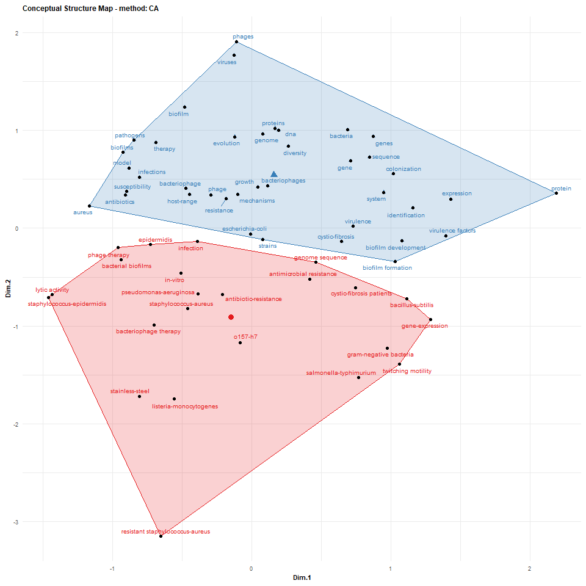

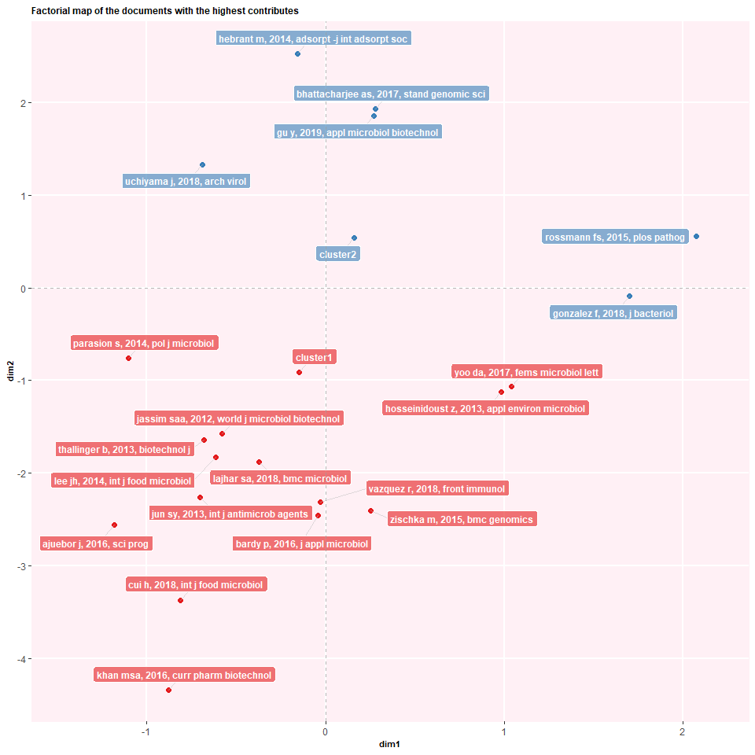

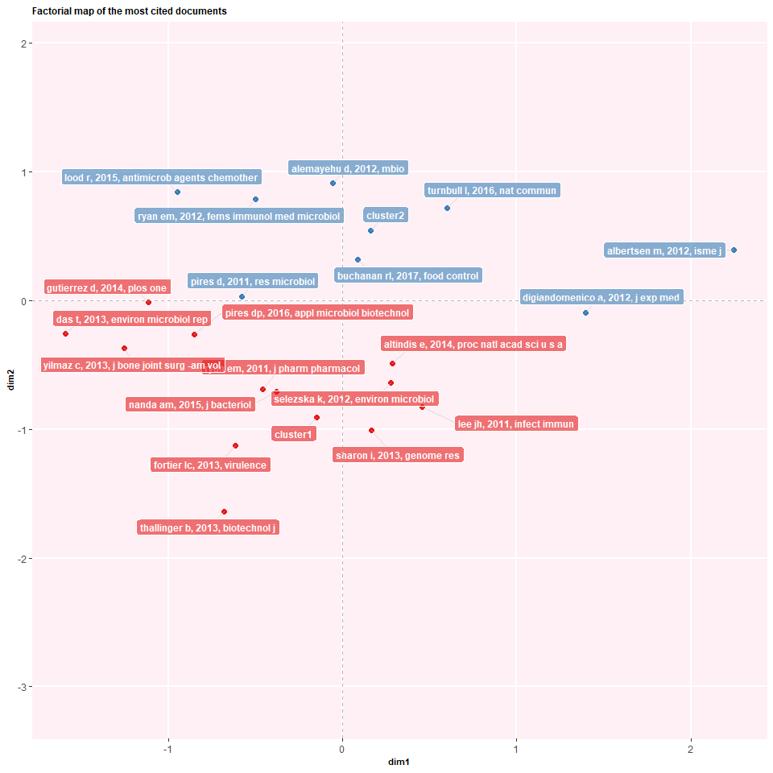

```r
CS <- conceptualStructure(M, method="CA", field="ID", minDegree=10, k.max = 8, stemming=f, labelsize=8,documents=20)
```

# Section 5: Thematic Map

Please see Cobo, M. J., L?pez-Herrera, A. G., Herrera-Viedma, E., & Herrera, F. (2011). An approach for detecting, quantifying, and visualizing the evolution of a research field: A practical application to the fuzzy sets theory field. Journal of Informetrics, 5(1), 146-166.

Cluster description

```r
Clusters=Map$words[order(Map$words$Cluster,-Map$words$Occurrences),]
```

[output not shown]

# Section 6: The social structure - Collaboration Analysis

## Author collaboration network

```r
NetMatrix <- biblioNetwork(M, analysis = "collaboration",  network = "authors", sep = ";")
net=networkPlot(NetMatrix,  n = 50, Title = "Author collaboration",type = "auto", size=10,size.cex=T,edgesize = 3,labelsize=0.6)
```

[output not shown]

Descriptive analysis of author collaboration network characteristics

```r
netstat <- networkStat(NetMatrix)
summary(netstat,k=15)
```

[output not shown]

## Edu collaboration network

```r
NetMatrix <- biblioNetwork(M, analysis = "collaboration",  network = "universities", sep = ";")
net=networkPlot(NetMatrix,  n = 50, Title = "Edu collaboration",type = "auto", size=10,size.cex=T,edgesize = 3,labelsize=0.6)
```

[output not shown]

Descriptive analysis of edu collaboration network characteristics

```r
netstat <- networkStat(NetMatrix)
summary(netstat,k=15)
```

[output not shown]

## Country collaboration network

```r
M <- metaTagExtraction(M, Field = "AU_CO", sep = ";")
NetMatrix <- biblioNetwork(M, analysis = "collaboration",  network = "countries", sep = ";")
net=networkPlot(NetMatrix,  n = dim(NetMatrix)[1], Title = "Country collaboration",type = "sphere", size=10,size.cex=T,edgesize = 1,labelsize=0.6, cluster="none")
```

[output not shown]

Descriptive analysis of country collaboration network characteristics

```r
netstat <- networkStat(NetMatrix)
summary(netstat,k=15)
```

[output not shown]